# IODS course project

# Chapter 3: Logistic regression

**Part 0: Libraries used and overall setup**

Disclaimer: this first part looks a bit awful, but bear with me.

```r
rm(list=ls())

library(dplyr); library(ggplot2); library(GGally); library(readr); library(tidyr)
```

**Part 2: The data**

This data contains information about Portuguese students and their endeavours in life. We use it to analyze the subtle relationship of alcohol consumption and school performance. The variables are listed below.

```r
setwd("~/GitHub/IODS-project/data")

alc <- read.table("alc.txt")

colnames(alc)
```

```
##  [1] "school"     "sex"        "age"        "address"    "famsize"
##  [6] "Pstatus"    "Medu"       "Fedu"       "Mjob"       "Fjob"
## [11] "reason"     "nursery"    "internet"   "guardian"   "traveltime"
## [16] "studytime"  "failures"   "schoolsup"  "famsup"     "paid"
## [21] "activities" "higher"     "romantic"   "famrel"     "freetime"
## [26] "goout"      "Dalc"       "Walc"       "health"     "absences"
## [31] "G1"         "G2"         "G3"         "alc_use"    "high_use"
```

**Part 3: Choosing the variables** My variables of choice are:

*absences* - Which comes first: absences or alcohol use? Causality is a bit questionable, but one way to hypothesize this is that more hangovers ( ans as such absences) means more alcohol use. There is a likely positive correlation.

*romantic* - Most persons in romantic relationships tend to become ex-drinking buddies. This is an observation in life, not a hypothesis :D

*famsize* - Family size might be an unintuitive choice at first glimpse, but should one have many siblings, some of them might be older and thus be able to purchase alcohol for their younger siblings. Personal experiances tell me, that this is one of the main supply channels of alcohol for young people.

*studytime* - Time spent studying is time away from drinking - as time spent drinking is time away from studying. Causality is again bit hard, but there will likely be a negative correlation.

**Part 4: Exploring the chosen variables**

The graphs indicate that over 2/3 of the students drink moderately. Two thirds is not romantically involved. Two thirds of the sample have more than 3 family members and it their weekly study time rarely exceeds 10 hours.

Regarding the cross-tabulations, I grouped moderate (including teatotallers) and heavy users i) according to their family size and ii) according to their romantic status.

It seems that children in bigger families do not drink heavily: It is more common for the children in the smaller families to consume high amounts of alcohol. On average, the high-users from bigger families are less absent than high-users from smaller families. The high-users average study time is smaller than of the student’s who drink moderately, but there seems to be no big (or interestening) difference regarding the family size. My hypothesis regarding family size seems to be highly questionable.

For persons in a romantic relationship, there seem to be more absences for both the moderate and heavy drinkers when compared to non-relationship persons (probably spending time together, awww). If the romantic status is associated with high levels of alcohol use, the mean absences get even bigger (maybe they are drinking together more often?).

It must be noted, that heavy drinkers might not be that great significant other -material: they might be more interested in partying than datin, as such there might be selection problems and numerous other mechanisms/channels that I haven’t even thought of.

```r
chosenvars <- c("absences", "romantic", "famsize", "studytime", "high_use", "sex")
alc2 <- select(alc, one_of(chosenvars))
str(alc2)
```

```
## 'data.frame':    382 obs. of  6 variables:
##  $ absences : int  5 3 8 1 2 8 0 4 0 0 ...
##  $ romantic : Factor w/ 2 levels "no","yes": 1 1 1 2 1 1 1 1 1 1 ...
##  $ famsize  : Factor w/ 2 levels "GT3","LE3": 1 1 2 1 1 2 2 1 2 1 ...
##  $ studytime: int  2 2 2 3 2 2 2 2 2 2 ...
##  $ high_use : logi  FALSE FALSE TRUE FALSE FALSE FALSE ...
##  $ sex      : Factor w/ 2 levels "F","M": 1 1 1 1 1 2 2 1 2 2 ...
```

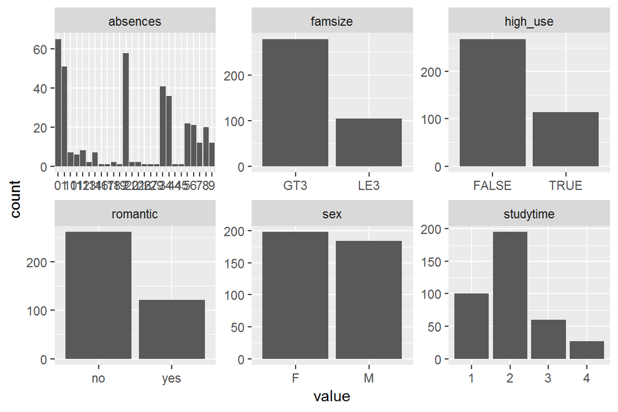

```r
gather(alc2) %>% ggplot(aes(value)) + facet_wrap("key", scales = "free") + geom_bar()
```

```r
alc %>% group_by(famsize, high_use) %>% summarise(count = n(), mean_absences = mean(absences), mean_studytime = mean(studytime))
```

```
## # A tibble: 4 x 5
## # Groups:   famsize [?]
##   famsize high_use count mean_absences mean_studytime
##   <fct>   <lgl>    <int>         <dbl>          <dbl>
## 1 GT3     FALSE      201          3.75           2.17
## 2 GT3     TRUE        77          6.05           1.79
## 3 LE3     FALSE       67          3.58           2.07
## 4 LE3     TRUE        37          7.03           1.73
```

```r
alc %>% group_by(romantic, high_use) %>% summarise(count = n(), mean_absences = mean(absences), mean_studytime = mean(studytime))
```

```
## # A tibble: 4 x 5
## # Groups:   romantic [?]
##   romantic high_use count mean_absences mean_studytime
##   <fct>    <lgl>    <int>         <dbl>          <dbl>
## 1 no       FALSE      180          3.41           2.16
## 2 no       TRUE        81          5.78           1.69
## 3 yes      FALSE       88          4.32           2.12
## 4 yes      TRUE        33          7.82           1.97
```

**Part 5: Logistic regression to the rescue**

It must be noted, that intuition tells me that the regression equation is “a bit dirty”. Study time and absences are probably correlated as heck, and combining an alcohol use indicator with absences and study time as such, well it sounds like an unholy triangle regarding the statistical inference.

*Interpretation of the summary and the odds ratios*

From my variables, study time and absences are statistically significant. More time spent studying indicates less heavy boozing and more absences probably indicates recovering from this heavy boozing (or something else, this is just a hypothesis).

The coeffient for study time is -0.53 (OR: 0.59) and the coefficient for absences 0.08 (OR: 1.09). The meaning of the raw coefficients is not that intuitive. The signs [+,-] and the magnitude of the coefficients are a bit informative, but if we exponent them, we change them to odds ratios.

For example an odds ratio of 0.59 with the study time indicates that a jump into a higher studying group (or category, as this is a categorical variable gaining the values 1-4) decreases the odds of drinking heavily. Vice versa, this means that a jump to a group of students that studies less (as it is a categorical variable gaining the values 1-4), makes the odds of drinking heavily (1/0.59) 1.69 times bigger. For the absences, one extra absence makes the odds of being a heavy drinker 1.08 times bigger.

```r
m <- glm(high_use ~ absences + romantic + famsize + studytime, data = alc, family = "binomial")

OR <- coef(m) %>% exp

CI <- confint(m) %>% exp
summary(m)
```

```
##
## Call:
## glm(formula = high_use ~ absences + romantic + famsize + studytime,
##     family = "binomial", data = alc)
##
## Deviance Residuals:
##     Min       1Q   Median       3Q      Max
## -2.1302  -0.8348  -0.6421   1.1824   2.2477
##
## Coefficients:
##             Estimate Std. Error z value Pr(>|z|)
## (Intercept) -0.22264    0.35314  -0.630 0.528393
## absences     0.08236    0.02300   3.581 0.000342 ***
## romanticyes -0.26346    0.25913  -1.017 0.309299
## famsizeLE3   0.31521    0.25692   1.227 0.219867
## studytime   -0.53031    0.15542  -3.412 0.000645 ***
## ---
## Signif. codes:  0 '***' 0.001 '**' 0.01 '*' 0.05 '.' 0.1 ' ' 1
##
## (Dispersion parameter for binomial family taken to be 1)
##
##     Null deviance: 465.68  on 381  degrees of freedom
## Residual deviance: 431.24  on 377  degrees of freedom
## AIC: 441.24
##
## Number of Fisher Scoring iterations: 4
```

```r
cbind(OR, CI)
```

```
##                    OR     2.5 %    97.5 %
## (Intercept) 0.8004009 0.3996898 1.6005996
## absences    1.0858500 1.0402630 1.1385241
## romanticyes 0.7683888 0.4578880 1.2679157
## famsizeLE3  1.3705508 0.8239609 2.2609734
## studytime   0.5884228 0.4296281 0.7912992
```

**Part 6: Exploring the predictive power**

Well, it seems that my model is not that convincing.

```r
probabilities <- predict(m, type = "response")
alc <- mutate(alc, probability = probabilities)

alc <- mutate(alc, prediction = probability>0.5)
table(high_use = alc$high_use, prediction = alc$prediction)
```

```
##         prediction
## high_use FALSE TRUE
##    FALSE   257   11
##    TRUE     97   17
```

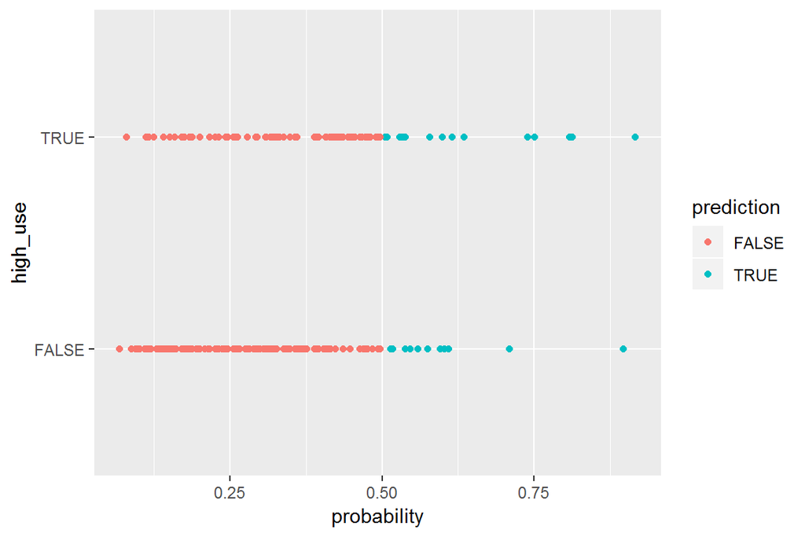

```r
g <- ggplot(alc, aes(x = probability, y = high_use, col=prediction))

g <- g +geom_point()
g
```

# Chapter 4: Clustering and classification

**Part 1: Libraries used and overall setup**

```r
rm(list=ls())

library(dplyr); library(ggplot2); library(GGally); library(readr); library(tidyr); library(MASS); library(corrplot)
```

**Part 2: The Boston housing dataset**

In order to analyze the median housing prices, the so called hedonic pricing method can be used. Hedonic prices is an highly influential idea developed by the late economist Shervin Rose in the 70s: the price of a good can be derived from its characteristics, but of course it can be turned the other way around as well, to analyze crime rates for instance as we are doing here.

Link to the data and its source information: https://stat.ethz.ch/R-manual/R-devel/library/MASS/html/Boston.html

```r
data("Boston")

dim(Boston)
```

```
## [1] 506  14
```

```r
str(Boston)
```

```
## 'data.frame':    506 obs. of  14 variables:
##  $ crim   : num  0.00632 0.02731 0.02729 0.03237 0.06905 ...
##  $ zn     : num  18 0 0 0 0 0 12.5 12.5 12.5 12.5 ...
##  $ indus  : num  2.31 7.07 7.07 2.18 2.18 2.18 7.87 7.87 7.87 7.87 ...
##  $ chas   : int  0 0 0 0 0 0 0 0 0 0 ...
##  $ nox    : num  0.538 0.469 0.469 0.458 0.458 0.458 0.524 0.524 0.524 0.524 ...
##  $ rm     : num  6.58 6.42 7.18 7 7.15 ...
##  $ age    : num  65.2 78.9 61.1 45.8 54.2 58.7 66.6 96.1 100 85.9 ...
##  $ dis    : num  4.09 4.97 4.97 6.06 6.06 ...
##  $ rad    : int  1 2 2 3 3 3 5 5 5 5 ...
##  $ tax    : num  296 242 242 222 222 222 311 311 311 311 ...
##  $ ptratio: num  15.3 17.8 17.8 18.7 18.7 18.7 15.2 15.2 15.2 15.2 ...
##  $ black  : num  397 397 393 395 397 ...
##  $ lstat  : num  4.98 9.14 4.03 2.94 5.33 ...
##  $ medv   : num  24 21.6 34.7 33.4 36.2 28.7 22.9 27.1 16.5 18.9 ...
```

**Part 3: The variables in the data**

As for the correlations, crime correlates negatively with housing prices, positively with accessibility to radial highways, the property tax rate and the percentages of lower status population. The median price correlates quite negatively with the percentages of lower status population, which is intuitive. The proximity to Charles River does not correlate that much with, well anything. This is somewhat surprising, as I would have imagined that it would be correlated with housing prices and ages at least.

```r
summary(Boston)
```

```
##       crim                zn             indus            chas
##  Min.   : 0.00632   Min.   :  0.00   Min.   : 0.46   Min.   :0.00000
##  1st Qu.: 0.08204   1st Qu.:  0.00   1st Qu.: 5.19   1st Qu.:0.00000
##  Median : 0.25651   Median :  0.00   Median : 9.69   Median :0.00000
##  Mean   : 3.61352   Mean   : 11.36   Mean   :11.14   Mean   :0.06917
##  3rd Qu.: 3.67708   3rd Qu.: 12.50   3rd Qu.:18.10   3rd Qu.:0.00000
##  Max.   :88.97620   Max.   :100.00   Max.   :27.74   Max.   :1.00000
##       nox               rm             age              dis
##  Min.   :0.3850   Min.   :3.561   Min.   :  2.90   Min.   : 1.130
##  1st Qu.:0.4490   1st Qu.:5.886   1st Qu.: 45.02   1st Qu.: 2.100
##  Median :0.5380   Median :6.208   Median : 77.50   Median : 3.207
##  Mean   :0.5547   Mean   :6.285   Mean   : 68.57   Mean   : 3.795
##  3rd Qu.:0.6240   3rd Qu.:6.623   3rd Qu.: 94.08   3rd Qu.: 5.188
##  Max.   :0.8710   Max.   :8.780   Max.   :100.00   Max.   :12.127
##       rad              tax           ptratio          black
##  Min.   : 1.000   Min.   :187.0   Min.   :12.60   Min.   :  0.32
##  1st Qu.: 4.000   1st Qu.:279.0   1st Qu.:17.40   1st Qu.:375.38
##  Median : 5.000   Median :330.0   Median :19.05   Median :391.44
##  Mean   : 9.549   Mean   :408.2   Mean   :18.46   Mean   :356.67
##  3rd Qu.:24.000   3rd Qu.:666.0   3rd Qu.:20.20   3rd Qu.:396.23
##  Max.   :24.000   Max.   :711.0   Max.   :22.00   Max.   :396.90
##      lstat            medv
##  Min.   : 1.73   Min.   : 5.00
##  1st Qu.: 6.95   1st Qu.:17.02
##  Median :11.36   Median :21.20
##  Mean   :12.65   Mean   :22.53
##  3rd Qu.:16.95   3rd Qu.:25.00
##  Max.   :37.97   Max.   :50.00
```

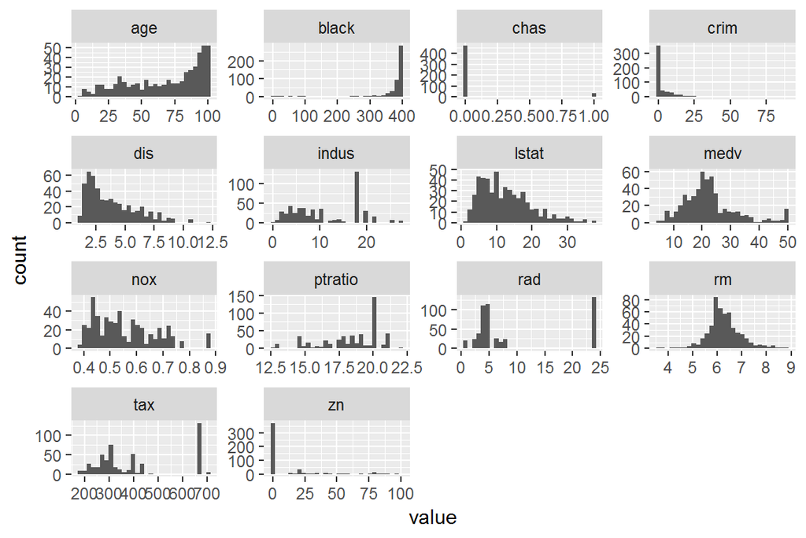

```r
gather(Boston)  %>% ggplot(aes(value)) + facet_wrap(~key, scales="free") + geom_histogram()
```

```r
cor_matrix<-cor(Boston) %>% round(2)
cor_matrix
```

```
##          crim    zn indus  chas   nox    rm   age   dis   rad   tax
## crim     1.00 -0.20  0.41 -0.06  0.42 -0.22  0.35 -0.38  0.63  0.58
## zn      -0.20  1.00 -0.53 -0.04 -0.52  0.31 -0.57  0.66 -0.31 -0.31
## indus    0.41 -0.53  1.00  0.06  0.76 -0.39  0.64 -0.71  0.60  0.72
## chas    -0.06 -0.04  0.06  1.00  0.09  0.09  0.09 -0.10 -0.01 -0.04
## nox      0.42 -0.52  0.76  0.09  1.00 -0.30  0.73 -0.77  0.61  0.67
## rm      -0.22  0.31 -0.39  0.09 -0.30  1.00 -0.24  0.21 -0.21 -0.29
## age      0.35 -0.57  0.64  0.09  0.73 -0.24  1.00 -0.75  0.46  0.51
## dis     -0.38  0.66 -0.71 -0.10 -0.77  0.21 -0.75  1.00 -0.49 -0.53
## rad      0.63 -0.31  0.60 -0.01  0.61 -0.21  0.46 -0.49  1.00  0.91
## tax      0.58 -0.31  0.72 -0.04  0.67 -0.29  0.51 -0.53  0.91  1.00
## ptratio  0.29 -0.39  0.38 -0.12  0.19 -0.36  0.26 -0.23  0.46  0.46
## black   -0.39  0.18 -0.36  0.05 -0.38  0.13 -0.27  0.29 -0.44 -0.44
## lstat    0.46 -0.41  0.60 -0.05  0.59 -0.61  0.60 -0.50  0.49  0.54
## medv    -0.39  0.36 -0.48  0.18 -0.43  0.70 -0.38  0.25 -0.38 -0.47
##         ptratio black lstat  medv
## crim       0.29 -0.39  0.46 -0.39
## zn        -0.39  0.18 -0.41  0.36
## indus      0.38 -0.36  0.60 -0.48
## chas      -0.12  0.05 -0.05  0.18
## nox        0.19 -0.38  0.59 -0.43
## rm        -0.36  0.13 -0.61  0.70
## age        0.26 -0.27  0.60 -0.38
## dis       -0.23  0.29 -0.50  0.25
## rad        0.46 -0.44  0.49 -0.38
## tax        0.46 -0.44  0.54 -0.47
## ptratio    1.00 -0.18  0.37 -0.51
## black     -0.18  1.00 -0.37  0.33
## lstat      0.37 -0.37  1.00 -0.74
## medv      -0.51  0.33 -0.74  1.00
```

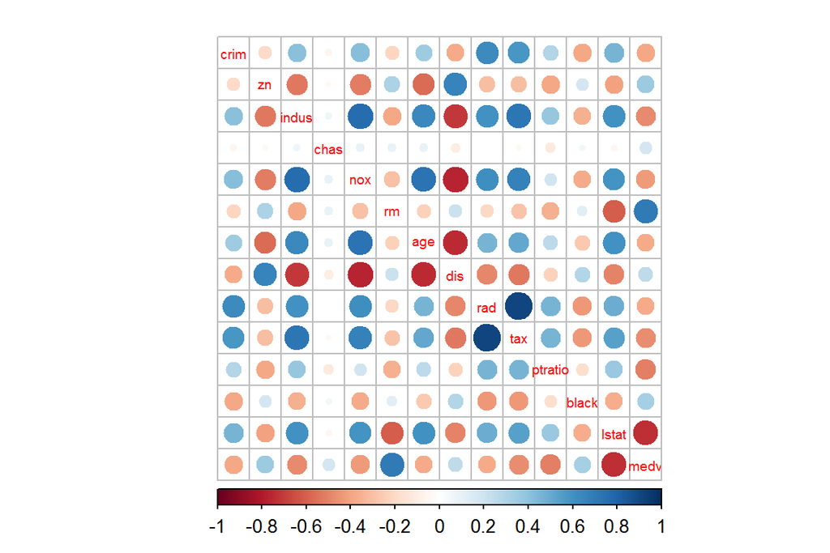

```r
corrplot(cor_matrix, method="circle", cl.pos = "b", tl.pos = "d", tl.cex = 0.6)
```

**Part 4: Standardizing the variables and other stuff**

Standardizing variables or an entire dataset can be done for numerous reasons like for the sake of easier comparability. After the scaling, the variables’ distributions look exactly the same, but they are rescaled to have a mean of zero and standard deviation of one.

```r
boston_scaled <- scale(Boston)
summary(boston_scaled)
```

```
##       crim                 zn               indus
##  Min.   :-0.419367   Min.   :-0.48724   Min.   :-1.5563
##  1st Qu.:-0.410563   1st Qu.:-0.48724   1st Qu.:-0.8668
##  Median :-0.390280   Median :-0.48724   Median :-0.2109
##  Mean   : 0.000000   Mean   : 0.00000   Mean   : 0.0000
##  3rd Qu.: 0.007389   3rd Qu.: 0.04872   3rd Qu.: 1.0150
##  Max.   : 9.924110   Max.   : 3.80047   Max.   : 2.4202
##       chas              nox                rm               age
##  Min.   :-0.2723   Min.   :-1.4644   Min.   :-3.8764   Min.   :-2.3331
##  1st Qu.:-0.2723   1st Qu.:-0.9121   1st Qu.:-0.5681   1st Qu.:-0.8366
##  Median :-0.2723   Median :-0.1441   Median :-0.1084   Median : 0.3171
##  Mean   : 0.0000   Mean   : 0.0000   Mean   : 0.0000   Mean   : 0.0000
##  3rd Qu.:-0.2723   3rd Qu.: 0.5981   3rd Qu.: 0.4823   3rd Qu.: 0.9059
##  Max.   : 3.6648   Max.   : 2.7296   Max.   : 3.5515   Max.   : 1.1164
##       dis               rad               tax             ptratio
##  Min.   :-1.2658   Min.   :-0.9819   Min.   :-1.3127   Min.   :-2.7047
##  1st Qu.:-0.8049   1st Qu.:-0.6373   1st Qu.:-0.7668   1st Qu.:-0.4876
##  Median :-0.2790   Median :-0.5225   Median :-0.4642   Median : 0.2746
##  Mean   : 0.0000   Mean   : 0.0000   Mean   : 0.0000   Mean   : 0.0000
##  3rd Qu.: 0.6617   3rd Qu.: 1.6596   3rd Qu.: 1.5294   3rd Qu.: 0.8058
##  Max.   : 3.9566   Max.   : 1.6596   Max.   : 1.7964   Max.   : 1.6372
##      black             lstat              medv
##  Min.   :-3.9033   Min.   :-1.5296   Min.   :-1.9063
##  1st Qu.: 0.2049   1st Qu.:-0.7986   1st Qu.:-0.5989
##  Median : 0.3808   Median :-0.1811   Median :-0.1449
##  Mean   : 0.0000   Mean   : 0.0000   Mean   : 0.0000
##  3rd Qu.: 0.4332   3rd Qu.: 0.6024   3rd Qu.: 0.2683
##  Max.   : 0.4406   Max.   : 3.5453   Max.   : 2.9865
```

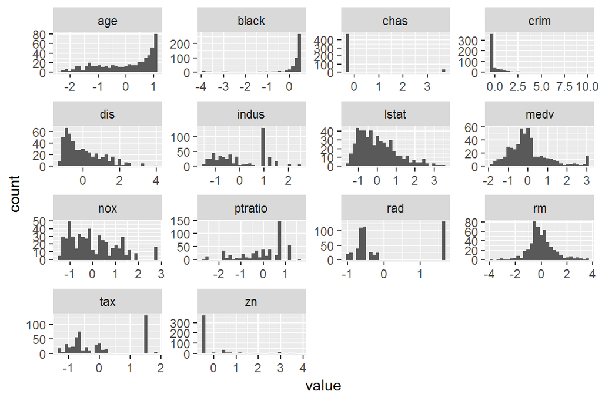

```r
boston_scaled <- as.data.frame(boston_scaled)
gather(boston_scaled)  %>% ggplot(aes(value)) + facet_wrap(~key, scales="free") + geom_histogram()
```

```r
bins <- quantile(boston_scaled$crim)
bins
```

```
##           0%          25%          50%          75%         100%
## -0.419366929 -0.410563278 -0.390280295  0.007389247  9.924109610
```

```r
label <- c("low","med_low","med_high","high")
crime <- cut(boston_scaled$crim, breaks = bins, labels = label, include.lowest = TRUE)
boston_scaled <- dplyr::select(boston_scaled, -crim)
boston_scaled <- data.frame(boston_scaled, crime)


n <- nrow(boston_scaled)
ind <- sample(n,  size = n * 0.8)
train <- boston_scaled[ind,]
test <- boston_scaled[-ind,]
correct_classes <- test$crime
test <- dplyr::select(test, -crime)
```

**Part 5: Linear discriminant analysis**

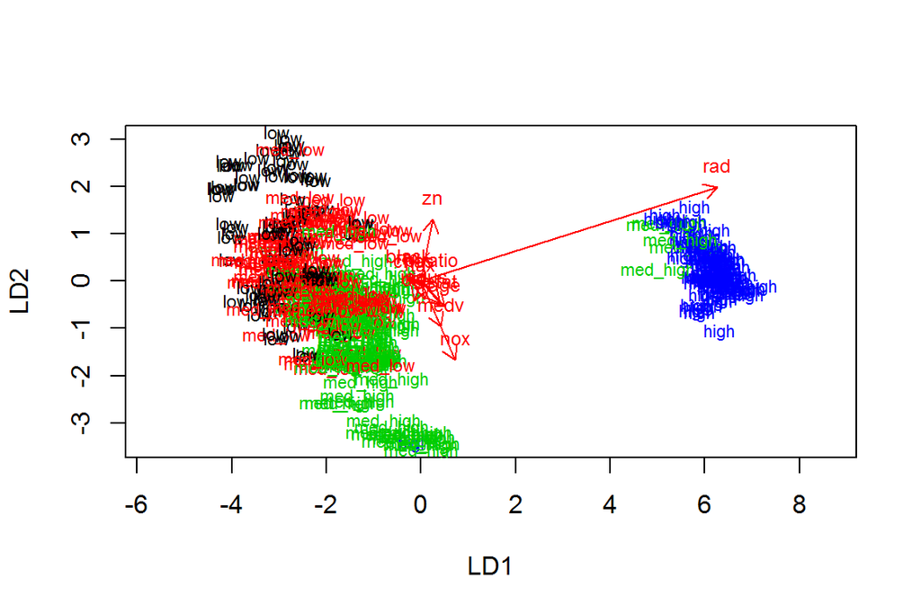

```r
lda.fit <- lda(crime ~ ., data = train)

lda.arrows <- function(x, myscale = 1, arrow_heads = 0.1, color = "red", tex = 0.75, choices = c(1,2)){
  heads <- coef(x)
  arrows(x0 = 0, y0 = 0,
         x1 = myscale * heads[,choices[1]],
         y1 = myscale * heads[,choices[2]], col=color, length = arrow_heads)
  text(myscale * heads[,choices], labels = row.names(heads),
       cex = tex, col=color, pos=3)
}

classes <- as.numeric(train$crime)

plot(lda.fit, dimen = 2, col = classes, pch = classes )
lda.arrows(lda.fit, myscale = 2)
```

**Part 6: Predicting with the model**

The reason why high crime suburbs are classified so well by the model can be seen from the LDA-plot: accessibility to radial highways seems to be a huge and distinctive factor in determining these suburbs. “Radan varrella sattuu ja tapahtuu”, some Finns might say.

[figure not shown]

[Music recommendation: “Kuustoista kilsaa Kontulaan”](https://www.youtube.com/watch?v=LV_3XhfbNTY)

```r
lda.pred <- predict(lda.fit, newdata = test)

# cross tabulate the results
table(correct = correct_classes, predicted = lda.pred$class)
```

```
##           predicted
## correct    low med_low med_high high
##   low       14      13        0    0
##   med_low    4      14        5    0
##   med_high   0      13       11    1
##   high       0       0        0   27
```

**Part 7: Cluster analysis**

The optimal number of clusters seems to be 2. The model suggests that there are two kinds of suburbs in the city of Boston.

Since cluster analysis usually relies on the imagination of its user and Boston is a reputable city of Irish, I’m going to name these two kinds of suburb categories as “Carrot Top Hoods” (black cluster) and “True Kelt Dwellings” (red cluster).

```r
data("Boston")
boston_scaled2 <- scale(Boston)
boston_scaled2 <- as.data.frame(boston_scaled2)

dist_eu <- dist(boston_scaled2)

summary(dist_eu)
```

```
##    Min. 1st Qu.  Median    Mean 3rd Qu.    Max.
##  0.1343  3.4625  4.8241  4.9111  6.1863 14.3970
```

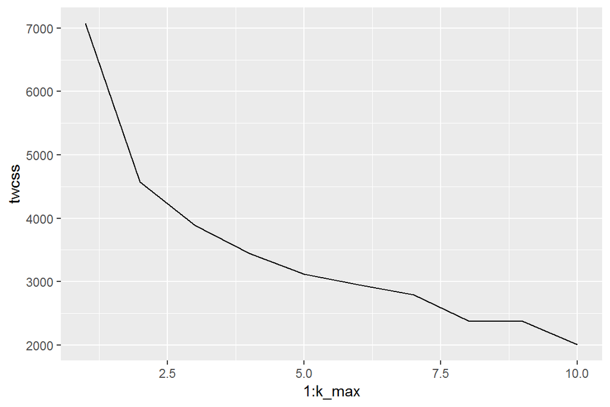

```r
# k-means clustering
km <-kmeans(boston_scaled2, centers = 3)

set.seed(123)
k_max <- 10
twcss <- sapply(1:k_max, function(k){kmeans(boston_scaled2, k)$tot.withinss})
qplot(x = 1:k_max, y = twcss, geom = 'line')
```

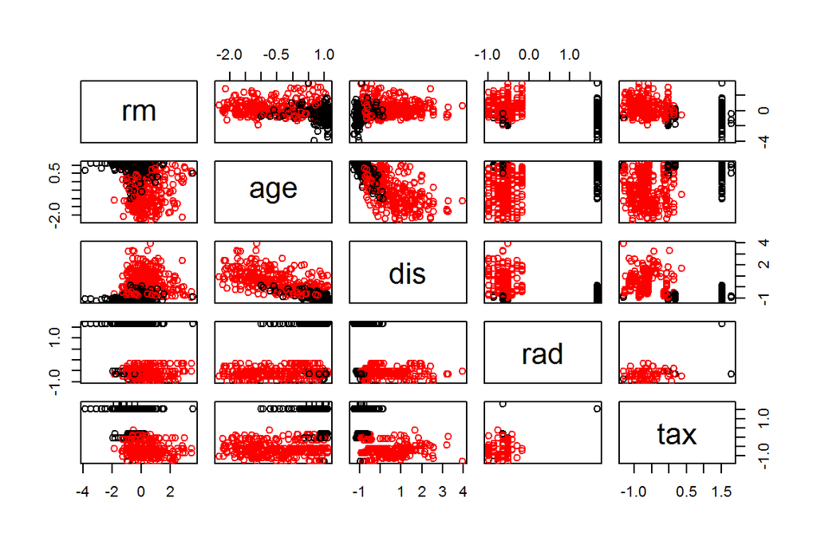

```r
km <-kmeans(boston_scaled2, centers = 2)

pairs(boston_scaled2[6:10], col = km$cluster)
```

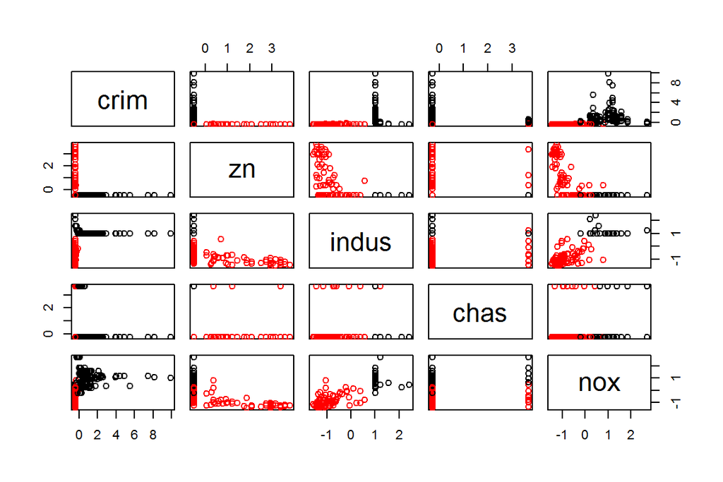

```r
pairs(boston_scaled2[1:5], col = km$cluster)
```

# Chapter 5: Dimensionality reduction techniques

**Part 0: Libraries used and overall setup**

```r
rm(list=ls())

library(dplyr); library(ggplot2); library(GGally); library(readr); library(tidyr); library(corrplot); library(FactoMineR)
```

**Part 1: Making sense of the data**

I’ll start by exploring ratios of labor force participation and secondary educative attainment between genders. Regarding the secondary educatio ratio, there are some countries, where there are more females with secondary education than makes, but overall, it seems that the ratio usually lies somewhere between 80% to 100% (as compared to males; 1 would mean equal amount of persons with secondary education). For the labor force participation rate, majority of countries lie between 0.5 and 1, but distribution of ratios is more uneven than the secondary education’s ratio and there are less cases where there are more females than males. For other participatory rates, females are less likely to be members of parliament, with the mean percent between countries being just 20.91.

As for the other variables, maternal mortality has some drastic outliers, as has life expectancy. A likely explanations for high maternal mortality and low life expectancy is poverty (and warfare, but we cannot identify it from the data) as there are strong negative correlations between GNI and maternal mortality and adolescent birth rates.  
For other correlations, life expectancy correlates strongly (+) with expected education years and life expectancy also has is strong negative correlations with maternal mortality rate and adolescent birth rate, which makes sense, as maternal mortality and adolescent birth rate seem to correspondingly correlate strongly (+).

```r
setwd("~/GitHub/IODS-project/data")

human <- read.table("human.txt")
```

```r
summary(human)
```

```
##     ed2r_FM           lfr_FM          Life_exp        Educ_exp
##  Min.   :0.1717   Min.   :0.1857   Min.   :49.00   Min.   : 5.40
##  1st Qu.:0.7264   1st Qu.:0.5984   1st Qu.:66.30   1st Qu.:11.25
##  Median :0.9375   Median :0.7535   Median :74.20   Median :13.50
##  Mean   :0.8529   Mean   :0.7074   Mean   :71.65   Mean   :13.18
##  3rd Qu.:0.9968   3rd Qu.:0.8535   3rd Qu.:77.25   3rd Qu.:15.20
##  Max.   :1.4967   Max.   :1.0380   Max.   :83.50   Max.   :20.20
##       GNI           Mat_mortr       Adol_birthr      Percent_MP_F
##  Min.   :   581   Min.   :   1.0   Min.   :  0.60   Min.   : 0.00
##  1st Qu.:  4198   1st Qu.:  11.5   1st Qu.: 12.65   1st Qu.:12.40
##  Median : 12040   Median :  49.0   Median : 33.60   Median :19.30
##  Mean   : 17628   Mean   : 149.1   Mean   : 47.16   Mean   :20.91
##  3rd Qu.: 24512   3rd Qu.: 190.0   3rd Qu.: 71.95   3rd Qu.:27.95
##  Max.   :123124   Max.   :1100.0   Max.   :204.80   Max.   :57.50
```

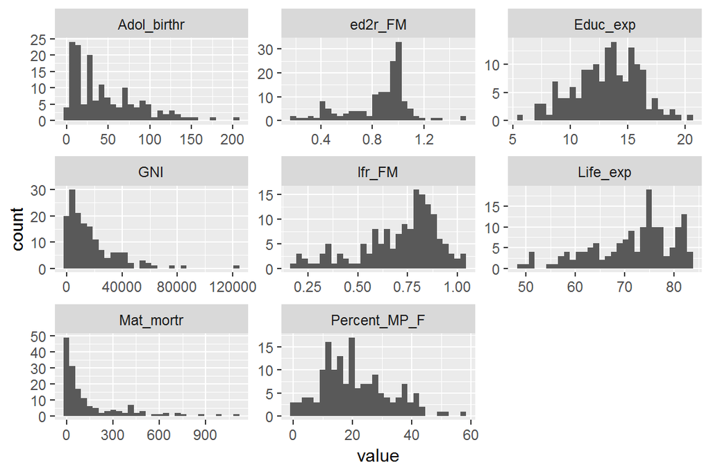

```r
gather(human)  %>% ggplot(aes(value)) + facet_wrap(~key, scales="free") + geom_histogram()
```

```r
M<-cor(human) %>% round(2)
M
```

```
##              ed2r_FM lfr_FM Life_exp Educ_exp   GNI Mat_mortr Adol_birthr
## ed2r_FM         1.00   0.01     0.58     0.59  0.43     -0.66       -0.53
## lfr_FM          0.01   1.00    -0.14     0.05 -0.02      0.24        0.12
## Life_exp        0.58  -0.14     1.00     0.79  0.63     -0.86       -0.73
## Educ_exp        0.59   0.05     0.79     1.00  0.62     -0.74       -0.70
## GNI             0.43  -0.02     0.63     0.62  1.00     -0.50       -0.56
## Mat_mortr      -0.66   0.24    -0.86    -0.74 -0.50      1.00        0.76
## Adol_birthr    -0.53   0.12    -0.73    -0.70 -0.56      0.76        1.00
## Percent_MP_F    0.08   0.25     0.17     0.21  0.09     -0.09       -0.07
##              Percent_MP_F
## ed2r_FM              0.08
## lfr_FM               0.25
## Life_exp             0.17
## Educ_exp             0.21
## GNI                  0.09
## Mat_mortr           -0.09
## Adol_birthr         -0.07
## Percent_MP_F         1.00
```

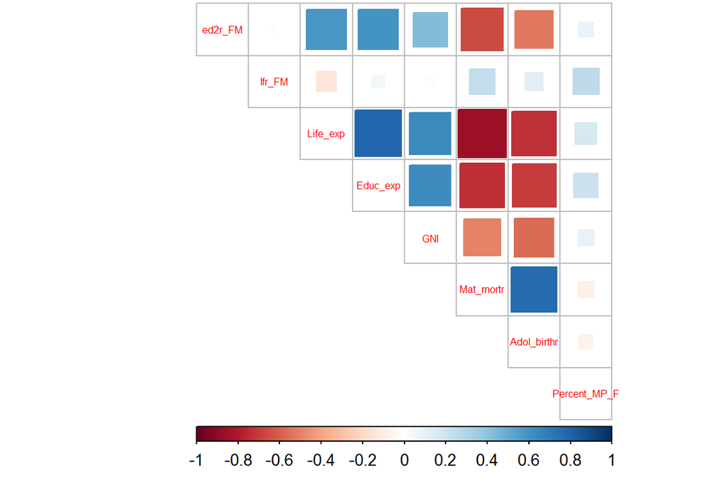

```r
corrplot(M, type = "upper", method="square", cl.pos = "b", tl.pos = "d", tl.cex = 0.5)
```

**Part 2: PCA with non-standardized variables**

[Comparison of non-standardized and standardized PCAs under Part 3.]

```r
pca_human <- prcomp(human)

s <- summary(pca_human)

pca_pr <- round(100*s$importance[2, ], digits = 1)
pca_pr
```

```
## PC1 PC2 PC3 PC4 PC5 PC6 PC7 PC8
## 100   0   0   0   0   0   0   0
```

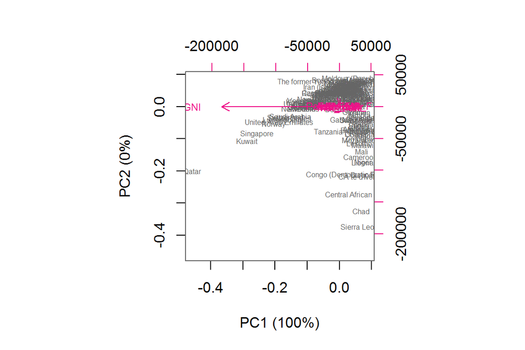

```r
pc_lab <- paste0(names(pca_pr), " (", pca_pr, "%)")

biplot(pca_human, cex = c(0.5, 0.7), col = c("grey40", "deeppink2"), xlab = pc_lab[1], ylab = pc_lab[2])
```

**Part 3: Comparison between PCAs: non-standardized vs standardized variables**

PCA does not funk that well if the variables are not standardized. This is due to the variable scaling: especially GNI seems to vary on a large scale as compared to other variables, which makes the analysis futile. As such, there’s not that much sense in trying to decipher these results, besides understanding that the analysis is ruined by one rampantly varying variable.

[figure not shown]

**My face whilst trying to decipher the results**

After we have standardized the variables, the results are very different and the biplot and the components seem meaningful.

A word about PCA, if you may. If we have a ton of variables, many of the variables can measure related attributes and as such are “redundant” in the analysis. In other words, they can measure the same phenomena and as such the same underlying things might affect them. For instance, intuition tells, that female to male labor force participation rate and the percentage of female parliament members are closely correlated outcomes determined by similar things in the society (religion, empowerment of females etc.) and as such, in general they measure the same phenomenon. In general that is, of course there might be drastic exceptions.

Based on the original variables, PCA constructs variables that capture the maximum amount of variance of the variables in the original data and can be used to reduce dimensions used in statistical analysis. Or to be precise, the first component captures maximum amount of variance, the second component captures maximum amount of variance left after the first one and so on. The principal components are uncorrelated, which is useful, since the original data can be a real cluster of heavily correlated variables. In this case, the two principal components depicted in the biplot capture 69,8% of the variance between countries.

We can analyze the first two components in the following manner with the biplot below.

- The arrow length
  - proportional to the standard deviation of the variable.
  - longer arrows mean more variance.
- The arrow angles regarding other arrows
  - Tells about correlation between the variables.
  - Example: maternal mortality and adolescent birth rates are positively correlated as the angle is quite small.
  - The two variables measuring female participation in labor markets and parliament of which arrows are orthogonal to these two are not correlated with maternal mortality nor adolescent birth rates, which is somewhat surprising.
- The arrow direction regarding the principal components
  - The arrows aligned with x- or y-axis tell which principal component they are most correlated with.
  - For instance, the two variables measuring female participation in labor markets and politics are aligned with y-axis and correlated with principal component2, while the other variables aligned mostly with x-axis are correlated with PC1.

```r
human_std <- scale(human)
summary(human_std)
```

```
##     ed2r_FM            lfr_FM           Life_exp          Educ_exp
##  Min.   :-2.8189   Min.   :-2.6247   Min.   :-2.7188   Min.   :-2.7378
##  1st Qu.:-0.5233   1st Qu.:-0.5484   1st Qu.:-0.6425   1st Qu.:-0.6782
##  Median : 0.3503   Median : 0.2316   Median : 0.3056   Median : 0.1140
##  Mean   : 0.0000   Mean   : 0.0000   Mean   : 0.0000   Mean   : 0.0000
##  3rd Qu.: 0.5958   3rd Qu.: 0.7350   3rd Qu.: 0.6717   3rd Qu.: 0.7126
##  Max.   : 2.6646   Max.   : 1.6632   Max.   : 1.4218   Max.   : 2.4730
##       GNI            Mat_mortr        Adol_birthr       Percent_MP_F
##  Min.   :-0.9193   Min.   :-0.6992   Min.   :-1.1325   Min.   :-1.8203
##  1st Qu.:-0.7243   1st Qu.:-0.6496   1st Qu.:-0.8394   1st Qu.:-0.7409
##  Median :-0.3013   Median :-0.4726   Median :-0.3298   Median :-0.1403
##  Mean   : 0.0000   Mean   : 0.0000   Mean   : 0.0000   Mean   : 0.0000
##  3rd Qu.: 0.3712   3rd Qu.: 0.1932   3rd Qu.: 0.6030   3rd Qu.: 0.6127
##  Max.   : 5.6890   Max.   : 4.4899   Max.   : 3.8344   Max.   : 3.1850
```

```r
pca_humanstd <- prcomp(human_std)

z <- summary(pca_humanstd)

pca_prz <- round(100*z$importance[2, ], digits = 1)

# print out the percentages of variance
pca_prz
```

```
##  PC1  PC2  PC3  PC4  PC5  PC6  PC7  PC8
## 53.6 16.2  9.6  7.6  5.5  3.6  2.6  1.3
```

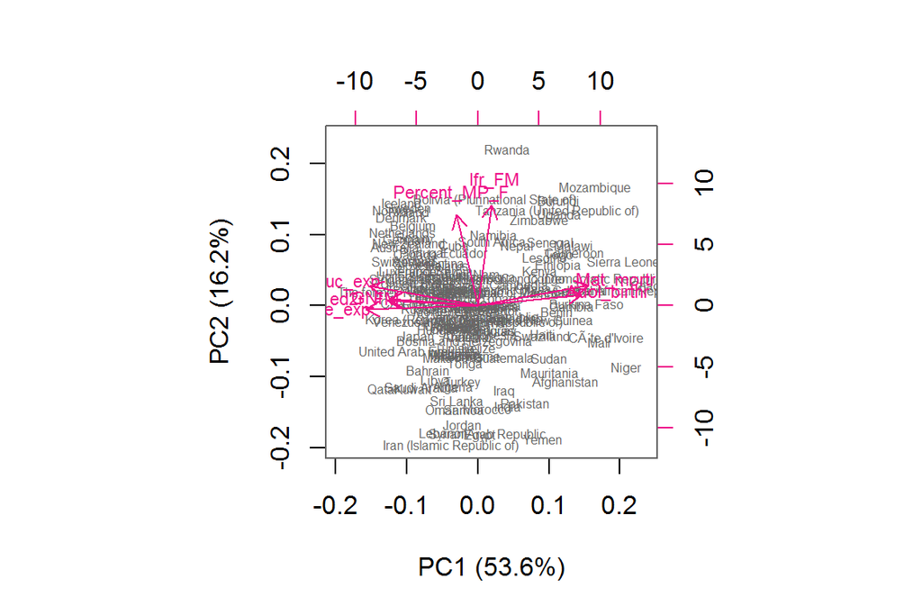

```r
# create object pc_lab to be used as axis labels
pc_labz <- paste0(names(pca_prz), " (", pca_prz, "%)")

# draw a biplot
biplot(pca_humanstd, cex = c(0.5, 0.7), col = c("grey40", "deeppink2"), xlab = pc_labz[1], ylab = pc_labz[2])
```

**Part 4: Personal interpretation of the biplot components**

In this case, the two principal components depicted in the biplot above capture 69,8% of the variance between countries.

The components and their main variables (as taken from the biplot arrows’ directions):

Female-male labour force participation and percentages of females as members of parliament contribute most to the PC2. I name this as the *FEMALE PARTICIPATION PRINCIPAL COMPONENT*. Female participation in politics and in labor markets seems to be a differentiate factor in analyzing the countries.

Expected education, GNI, life expectancy and female-male secondary educational attainment rate (all of them positively correlated + to PC1) as well negatively correlated maternal mortality and adolescent birth rates contribute most to the PC1. I name this *OVERALL DEVELOPMENT PRINCIPAL COMPONENT*.

So basically, we have the overall development and female participation components and they capture almost 70% of the variance between countries.

**Part 5: Multiple correspondence analysis**

Since there’s a load of variables, 36 to be exact, with a total of 300 observations, I’m going to limit the number of variables used in the analysis as done with the data camp exercises. All but one variables are factor variables, with at least 2 levels. The only integer variable is age. So basically, we have some tea drinkers here and we are trying to summarize what drives different their tea drinking.

Sooo, MCA is sort of PCA, except for it is used for factor variables. The components explain variance in the manner as with PCA.In the biplot, factor levels with similar profile are in close proximity to each other. What I find interesting, are the following combinations (and my interpretations):

*Teatime + pub + tea bag & unpackaged - Sounds like a highly British combination. Tea, teatime and the local village pub.

*Earl Grey + spirituality - If the nationality of the people that the sample covers is British, then this is an understandable combination! But for some reason, I would have anticipated green tea to be closer to spirituality. Maybe I don’t understand that much about tea drinking.

*Green tea + not tea time - Well sort of makes sense as green tea drinkers might not be the traditional British tea drinkers. Maybe I don’t understand anything about tea drinking.

By the way, MCA reminds me of Beastie Boys.

[figure not shown]

[Music recommendation: “Sabotage”](https://www.youtube.com/watch?v=z5rRZdiu1UE)

```r
data("tea")

str(tea)
```

```
## 'data.frame':    300 obs. of  36 variables:
##  $ breakfast       : Factor w/ 2 levels "breakfast","Not.breakfast": 1 1 2 2 1 2 1 2 1 1 ...
##  $ tea.time        : Factor w/ 2 levels "Not.tea time",..: 1 1 2 1 1 1 2 2 2 1 ...
##  $ evening         : Factor w/ 2 levels "evening","Not.evening": 2 2 1 2 1 2 2 1 2 1 ...
##  $ lunch           : Factor w/ 2 levels "lunch","Not.lunch": 2 2 2 2 2 2 2 2 2 2 ...
##  $ dinner          : Factor w/ 2 levels "dinner","Not.dinner": 2 2 1 1 2 1 2 2 2 2 ...
##  $ always          : Factor w/ 2 levels "always","Not.always": 2 2 2 2 1 2 2 2 2 2 ...
##  $ home            : Factor w/ 2 levels "home","Not.home": 1 1 1 1 1 1 1 1 1 1 ...
##  $ work            : Factor w/ 2 levels "Not.work","work": 1 1 2 1 1 1 1 1 1 1 ...
##  $ tearoom         : Factor w/ 2 levels "Not.tearoom",..: 1 1 1 1 1 1 1 1 1 2 ...
##  $ friends         : Factor w/ 2 levels "friends","Not.friends": 2 2 1 2 2 2 1 2 2 2 ...
##  $ resto           : Factor w/ 2 levels "Not.resto","resto": 1 1 2 1 1 1 1 1 1 1 ...
##  $ pub             : Factor w/ 2 levels "Not.pub","pub": 1 1 1 1 1 1 1 1 1 1 ...
##  $ Tea             : Factor w/ 3 levels "black","Earl Grey",..: 1 1 2 2 2 2 2 1 2 1 ...
##  $ How             : Factor w/ 4 levels "alone","lemon",..: 1 3 1 1 1 1 1 3 3 1 ...
```

[output cut: 22 more lines]

```r
dim(tea)
```

```
## [1] 300  36
```

```r
summary(tea)
```

```
##          breakfast           tea.time          evening          lunch
##  breakfast    :144   Not.tea time:131   evening    :103   lunch    : 44
##  Not.breakfast:156   tea time    :169   Not.evening:197   Not.lunch:256
##
##
##
##
##
##         dinner           always          home           work
##  dinner    : 21   always    :103   home    :291   Not.work:213
##  Not.dinner:279   Not.always:197   Not.home:  9   work    : 87
##
##
##
##
##
##         tearoom           friends          resto          pub
##  Not.tearoom:242   friends    :196   Not.resto:221   Not.pub:237
##  tearoom    : 58   Not.friends:104   resto    : 79   pub    : 63
##
##
##
##
##
##         Tea         How           sugar                     how
##  black    : 74   alone:195   No.sugar:155   tea bag           :170
##  Earl Grey:193   lemon: 33   sugar   :145   tea bag+unpackaged: 94
##  green    : 33   milk : 63                  unpackaged        : 36
##                  other:  9
##
##
##
##                   where                 price          age        sex
##  chain store         :192   p_branded      : 95   Min.   :15.00   F:178
##  chain store+tea shop: 78   p_cheap        :  7   1st Qu.:23.00   M:122
##  tea shop            : 30   p_private label: 21   Median :32.00
##                             p_unknown      : 12   Mean   :37.05
##                             p_upscale      : 53   3rd Qu.:48.00
##                             p_variable     :112   Max.   :90.00
##
```

[output cut: 25 more lines]

```
##  feminine    :129   Not.sophisticated: 85   No.slimming:255
##  Not.feminine:171   sophisticated    :215   slimming   : 45
##
##
##
##
##
##         exciting          relaxing              effect.on.health
##  exciting   :116   No.relaxing:113   effect on health   : 66
##  No.exciting:184   relaxing   :187   No.effect on health:234
##
##
##
##
##
```

```r
tea_time <- tea[,c("Tea", "how", "spirituality", "tearoom", "pub", "tea.time")]

mca <- MCA(tea_time, graph = FALSE)

summary(mca)
```

```
##
## Call:
## MCA(X = tea_time, graph = FALSE)
##
##
## Eigenvalues
##                        Dim.1   Dim.2   Dim.3   Dim.4   Dim.5   Dim.6
## Variance               0.258   0.214   0.183   0.165   0.144   0.134
## % of var.             19.364  16.050  13.696  12.401  10.789  10.054
## Cumulative % of var.  19.364  35.414  49.110  61.511  72.301  82.354
##                        Dim.7   Dim.8
## Variance               0.124   0.112
## % of var.              9.271   8.375
## Cumulative % of var.  91.625 100.000
##
## Individuals (the 10 first)
##                       Dim.1    ctr   cos2    Dim.2    ctr   cos2    Dim.3
## 1                  | -0.527  0.359  0.275 |  0.502  0.392  0.249 | -0.323
## 2                  | -0.527  0.359  0.275 |  0.502  0.392  0.249 | -0.323
## 3                  | -0.175  0.040  0.060 | -0.061  0.006  0.007 | -0.464
## 4                  | -0.515  0.342  0.299 | -0.558  0.485  0.352 |  0.123
## 5                  | -0.515  0.342  0.299 | -0.558  0.485  0.352 |  0.123
## 6                  | -0.596  0.459  0.598 | -0.130  0.026  0.028 | -0.245
## 7                  | -0.175  0.040  0.060 | -0.061  0.006  0.007 | -0.464
## 8                  | -0.106  0.015  0.012 |  0.571  0.508  0.352 | -0.542
## 9                  |  0.204  0.054  0.056 | -0.032  0.002  0.001 | -0.071
## 10                 |  0.454  0.266  0.108 |  0.617  0.593  0.200 |  0.278
##                       ctr   cos2
## 1                   0.190  0.103 |
## 2                   0.190  0.103 |
## 3                   0.394  0.423 |
## 4                   0.027  0.017 |
## 5                   0.027  0.017 |
## 6                   0.110  0.101 |
## 7                   0.394  0.423 |
## 8                   0.536  0.317 |
## 9                   0.009  0.007 |
## 10                  0.141  0.040 |
##
## Categories (the 10 first)
```

[output cut: 16 more lines]

```
## tea bag+unpackaged   0.008  -1.558 |   0.571   9.318   0.149   6.668 |
## unpackaged           0.252   8.674 |   0.578   3.655   0.046   3.689 |
## Not.spirituality     0.303   9.522 |  -0.295   5.469   0.191  -7.562 |
## spirituality         0.303  -9.522 |   0.647  11.986   0.191   7.562 |
## Not.tearoom          0.009  -1.635 |  -0.103   0.775   0.044  -3.625 |
## tearoom              0.009   1.635 |   0.428   3.235   0.044   3.625 |
##
## Categorical variables (eta2)
##                      Dim.1 Dim.2 Dim.3
## Tea                | 0.094 0.581 0.505 |
## how                | 0.291 0.253 0.251 |
## spirituality       | 0.013 0.303 0.191 |
## tearoom            | 0.525 0.009 0.044 |
## pub                | 0.220 0.129 0.026 |
## tea.time           | 0.406 0.009 0.078 |
```

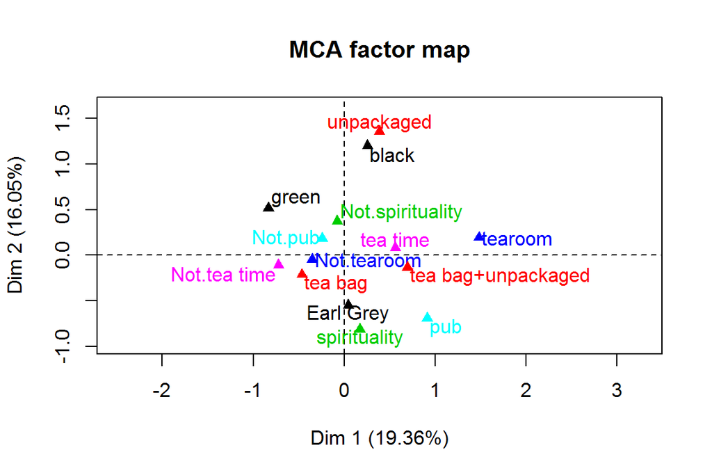

```r
plot(mca, invisible=c("ind"), habillage = "quali")
```